# personal-loan-logistic-regression-decision-tree

## Personal Loan Modelling

- Context
- Data Set
- Libraries
- Read and Understand Data
- Data Preprocessing
- Exploratory Data Analysis
  - Univariate Analysis
  - Bivariate and Multivariate Analysis
- Insights based on EDA
- Model Building Logistic Regression
- Model Building Decision Tree
- Conclusion
- Actionable Insights & Recommendations

### Context

Thera Bankis a US bank that has a growing customer base. The majority of these customers are liability customers (depositors) with varying sizes of deposits. The number of customers who are also borrowers (asset customers) is quite small, and the bank is interested in expanding this base rapidly to bring in more loan business and in the process, earn more through the interest on loans. In particular, the management wants to explore ways of converting its liability customers to personal loan customers (while retaining them as depositors). A campaign that the bank ran last year for liability customers showed a healthy conversion rate of over 9% success. This has encouraged the retail marketing department to devise campaigns with better target marketing to increase the success ratio. As a Data scientist at Thera Bank have to build a model that will help the marketing department to identify the potential customers who have a higher probability of purchasing the loan.

**Motivation : To understand Logistic regression and Decision tree and explore this algorthims using Sklearn, Statmodel, Roc-Auc Curve,Precision Curve,Sequential feature selection, hyperparamter tuning Decision tress and post pruning Decision trees**

### Data Dictionary

- ID: Customer ID
- Age: Customer’s age in completed years
- Experience: #years of professional experience
- Income: Annual income of the customer (in thousand dollars)
- ZIP Code: Home Address ZIP code.
- Family: the Family size of the customer
- CCAvg: Average spending on credit cards per month (in thousand dollars)
- Education: Education Level. 1: Undergrad; 2: Graduate;3: Advanced/Professional
- Mortgage: Value of house mortgage if any. (in thousand dollars)
- Personal_Loan: Did this customer accept the personal loan offered in the last campaign?
- Securities_Account: Does the customer have securities account with the bank?
- CD_Account: Does the customer have a certificate of deposit (CD) account with the bank?
- Online: Do customers use internet banking facilities?
- CreditCard: Does the customer use a credit card issued by any other Bank (excluding All life Bank)?

## Problem

- To predict whether a liability customer will buy a personal loan or not.
- Which variables are most significant.
- Which segment of customers should be targeted more.
- Does Age have any impact of customer buying loan?
- Do people with less income borrow loans .?

### Libraries

```python
!pip install zipcodes # installing Zipcodes library .
```

```
     |████████████████████████████████| 717 kB 419 kB/s
```

```python
### IMPORT: ------------------------------------
import scipy.stats as stats
import pandas as pd
import numpy as np
import zipcodes as zcode # to get zipcodes

import matplotlib.pyplot as plt
%matplotlib inline
import seaborn as sns
import warnings

import statsmodels.api as sm
#--Sklearn library--
# Sklearn package's randomized data splitting function
from sklearn.model_selection import train_test_split

from sklearn.metrics import confusion_matrix, classification_report
from sklearn.metrics import accuracy_score,precision_score,recall_score,f1_score
from statsmodels.stats.outliers_influence import variance_inflation_factor
from sklearn import metrics
#AUC ROC curve
from sklearn.metrics import roc_auc_score
from sklearn.metrics import roc_curve
from sklearn.metrics import precision_recall_curve

from sklearn.metrics import confusion_matrix,ConfusionMatrixDisplay #to plot confusion matric
from sklearn.metrics import plot_confusion_matrix

from sklearn.linear_model import LogisticRegression #to build the model
from sklearn.tree import DecisionTreeClassifier#to build the model

pd.set_option('display.float_format', lambda x: '%.3f' % x)
pd.set_option('display.max_rows', 300)
pd.set_option('display.max_colwidth',400)
pd.set_option('display.float_format', lambda x: '%.5f' % x)
# To supress numerical display in scientific notations
warnings.filterwarnings('ignore') # To supress warnings
 # set the background for the graphs
plt.style.use('ggplot')
```

# Read and Understand data

```python
#Reading the csv file  used car data.csv
data_path='../input/personal-loan-modeling/Bank_Personal_Loan_Modelling.csv'
df=pd.read_csv(data_path)
df_loan=df.copy()
print(f'There are {df_loan.shape[0]} rows and {df_loan.shape[1]} columns') # fstring
```

```
There are 5000 rows and 14 columns
```

```python
df_loan.head()
```

|  | ID | Age | Experience | Income | ZIP Code | Family | CCAvg | Education | Mortgage | Personal Loan | Securities Account | CD Account | Online | CreditCard |
| --- | --- | --- | --- | --- | --- | --- | --- | --- | --- | --- | --- | --- | --- | --- |
| 0 | 1 | 25 | 1 | 49 | 91107 | 4 | 1.60000 | 1 | 0 | 0 | 1 | 0 | 0 | 0 |
| 1 | 2 | 45 | 19 | 34 | 90089 | 3 | 1.50000 | 1 | 0 | 0 | 1 | 0 | 0 | 0 |
| 2 | 3 | 39 | 15 | 11 | 94720 | 1 | 1.00000 | 1 | 0 | 0 | 0 | 0 | 0 | 0 |
| 3 | 4 | 35 | 9 | 100 | 94112 | 1 | 2.70000 | 2 | 0 | 0 | 0 | 0 | 0 | 0 |
| 4 | 5 | 35 | 8 | 45 | 91330 | 4 | 1.00000 | 2 | 0 | 0 | 0 | 0 | 0 | 1 |

```python
df_loan.tail()
```

|  | ID | Age | Experience | Income | ZIP Code | Family | CCAvg | Education | Mortgage | Personal Loan | Securities Account | CD Account | Online | CreditCard |
| --- | --- | --- | --- | --- | --- | --- | --- | --- | --- | --- | --- | --- | --- | --- |
| 4995 | 4996 | 29 | 3 | 40 | 92697 | 1 | 1.90000 | 3 | 0 | 0 | 0 | 0 | 1 | 0 |
| 4996 | 4997 | 30 | 4 | 15 | 92037 | 4 | 0.40000 | 1 | 85 | 0 | 0 | 0 | 1 | 0 |
| 4997 | 4998 | 63 | 39 | 24 | 93023 | 2 | 0.30000 | 3 | 0 | 0 | 0 | 0 | 0 | 0 |
| 4998 | 4999 | 65 | 40 | 49 | 90034 | 3 | 0.50000 | 2 | 0 | 0 | 0 | 0 | 1 | 0 |
| 4999 | 5000 | 28 | 4 | 83 | 92612 | 3 | 0.80000 | 1 | 0 | 0 | 0 | 0 | 1 | 1 |

```python
#get the size of dataframe
print ("Rows     : " , df_loan.shape[0])  #get number of rows/observations
print ("Columns  : " , df_loan.shape[1]) #get number of columns
print ("#"*40,"\n","Features : \n\n", df_loan.columns.tolist()) #get name of columns/features
print ("#"*40,"\nMissing values :\n\n", df_loan.isnull().sum().sort_values(ascending=False))
print( "#"*40,"\nPercent of missing :\n\n", round(df_loan.isna().sum() / df_loan.isna().count() * 100, 2)) # looking at columns with most Missing Values
print ("#"*40,"\nUnique values :  \n\n", df_loan.nunique())  #  count of unique values
```

```
Rows     :  5000
Columns  :  14
########################################
 Features :

 ['ID', 'Age', 'Experience', 'Income', 'ZIP Code', 'Family', 'CCAvg', 'Education', 'Mortgage', 'Personal Loan', 'Securities Account', 'CD Account', 'Online', 'CreditCard']
########################################
Missing values :

 ID                    0
Age                   0
Experience            0
Income                0
ZIP Code              0
Family                0
CCAvg                 0
Education             0
Mortgage              0
Personal Loan         0
Securities Account    0
CD Account            0
Online                0
CreditCard            0
dtype: int64
########################################
Percent of missing :

 ID                   0.00000
Age                  0.00000
Experience           0.00000
Income               0.00000
ZIP Code             0.00000
Family               0.00000
CCAvg                0.00000
Education            0.00000
Mortgage             0.00000
Personal Loan        0.00000
Securities Account   0.00000
CD Account           0.00000
Online               0.00000
CreditCard           0.00000
dtype: float64
########################################
Unique values :

 ID                    5000
Age                     45
Experience              47
Income                 162
ZIP Code               467
Family                   4
CCAvg                  108
Education                3
Mortgage               347
Personal Loan            2
Securities Account       2
CD Account               2
Online                   2
CreditCard               2
dtype: int64
```

```python
df_loan.info()
```

```
<class 'pandas.core.frame.DataFrame'>
RangeIndex: 5000 entries, 0 to 4999
Data columns (total 14 columns):
 #   Column              Non-Null Count  Dtype
---  ------              --------------  -----
 0   ID                  5000 non-null   int64
 1   Age                 5000 non-null   int64
 2   Experience          5000 non-null   int64
 3   Income              5000 non-null   int64
 4   ZIP Code            5000 non-null   int64
 5   Family              5000 non-null   int64
 6   CCAvg               5000 non-null   float64
 7   Education           5000 non-null   int64
 8   Mortgage            5000 non-null   int64
 9   Personal Loan       5000 non-null   int64
 10  Securities Account  5000 non-null   int64
 11  CD Account          5000 non-null   int64
 12  Online              5000 non-null   int64
 13  CreditCard          5000 non-null   int64
dtypes: float64(1), int64(13)
memory usage: 547.0 KB
```

**There are no missing values in the dataset. All the columns are numerical here. `Personal loan` is target variable. Zipcode,Family,Education,Securities Account,CD_account,online,Credit card are all categorical variables.**

```python
df_loan.sample(10)
```

|  | ID | Age | Experience | Income | ZIP Code | Family | CCAvg | Education | Mortgage | Personal Loan | Securities Account | CD Account | Online | CreditCard |
| --- | --- | --- | --- | --- | --- | --- | --- | --- | --- | --- | --- | --- | --- | --- |
| 2015 | 2016 | 30 | 5 | 141 | 95747 | 1 | 0.80000 | 1 | 0 | 0 | 0 | 0 | 1 | 0 |
| 3414 | 3415 | 61 | 36 | 18 | 95010 | 1 | 1.30000 | 1 | 0 | 0 | 0 | 0 | 0 | 0 |
| 4773 | 4774 | 53 | 28 | 48 | 92029 | 2 | 1.90000 | 2 | 0 | 0 | 0 | 0 | 1 | 0 |
| 2892 | 2893 | 58 | 32 | 43 | 92093 | 1 | 2.80000 | 2 | 0 | 0 | 0 | 0 | 1 | 0 |
| 150 | 151 | 46 | 22 | 118 | 94107 | 2 | 7.50000 | 1 | 0 | 0 | 0 | 1 | 1 | 1 |
| 698 | 699 | 64 | 38 | 59 | 92028 | 1 | 2.50000 | 3 | 220 | 0 | 0 | 0 | 0 | 0 |
| 2071 | 2072 | 52 | 28 | 83 | 94705 | 1 | 0.00000 | 1 | 0 | 0 | 0 | 0 | 1 | 0 |
| 262 | 263 | 49 | 23 | 33 | 90245 | 1 | 0.30000 | 3 | 0 | 0 | 0 | 1 | 1 | 1 |
| 745 | 746 | 30 | 4 | 49 | 93955 | 3 | 1.10000 | 2 | 0 | 0 | 0 | 0 | 0 | 1 |
| 3068 | 3069 | 56 | 26 | 90 | 92120 | 2 | 4.50000 | 3 | 0 | 0 | 0 | 0 | 0 | 0 |

**`Id` column is not needed and can be dropped.**

```python
df_loan.drop(['ID'],axis=1,inplace=True) #droping id
```

### Processing Zipcode

Zipcode is a categorical feature and can be a good predictor of target variable. We can analyse if there is any pattern on location for customers who had borrowed loaned during previous campaign. Trying to see if we can reduce the category

```python
df_loan.rename(columns={"ZIP Code":"ZIPCode","Personal Loan":"PersonalLoan","Securities Account":"SecuritiesAccount","CD Account":'CDAccount'},inplace=True)
```

```python
df_loan.ZIPCode.nunique()
```

```
467
```

```python
# get unique zipcodes
list_zipcode=df_loan.ZIPCode.unique()
```

```python
#here i am creating a dictionary of county by using library zipcode and matching method.
dict_zip={}
for zipcode in list_zipcode:
    my_city_county = zcode.matching(zipcode.astype('str'))
    if len(my_city_county)==1: # if  zipcode is present then get county else, assign zipcode to county
        county=my_city_county[0].get('county')
    else:
        county=zipcode

    dict_zip.update({zipcode:county})
```

```python
dict_zip
```

```
{91107: 'Los Angeles County',
 90089: 'Los Angeles County',
 94720: 'Alameda County',
 94112: 'San Francisco County',
 91330: 'Los Angeles County',
 92121: 'San Diego County',
 91711: 'Los Angeles County',
 93943: 'Monterey County',
 93023: 'Ventura County',
 94710: 'Alameda County',
 90277: 'Los Angeles County',
 93106: 'Santa Barbara County',
 94920: 'Marin County',
 91741: 'Los Angeles County',
 95054: 'Santa Clara County',
```

[output cut: 452 more lines]

We got almost all county expect for `96651,92634,93077,92717`. We can fix this zip code by searching internet. Couldn't find for other zipcodes.

```python
dict_zip.update({92717:'Orange County'})
dict_zip.update({92634:'Orange County'})
```

```python
df_loan['County']=df_loan['ZIPCode'].map(dict_zip)
```

```python
df_loan.County.nunique()
```

```
40
```

```python
df_loan.info()
```

```
<class 'pandas.core.frame.DataFrame'>
RangeIndex: 5000 entries, 0 to 4999
Data columns (total 14 columns):
 #   Column             Non-Null Count  Dtype
---  ------             --------------  -----
 0   Age                5000 non-null   int64
 1   Experience         5000 non-null   int64
 2   Income             5000 non-null   int64
 3   ZIPCode            5000 non-null   int64
 4   Family             5000 non-null   int64
 5   CCAvg              5000 non-null   float64
 6   Education          5000 non-null   int64
 7   Mortgage           5000 non-null   int64
 8   PersonalLoan       5000 non-null   int64
 9   SecuritiesAccount  5000 non-null   int64
 10  CDAccount          5000 non-null   int64
 11  Online             5000 non-null   int64
 12  CreditCard         5000 non-null   int64
 13  County             5000 non-null   object
dtypes: float64(1), int64(12), object(1)
memory usage: 547.0+ KB
```

### Fixing the data types

Personal_Loan, Securities_Account, CD_Account, 'Online', 'CreditCard' ,Education are of int/object type, we can change them to category type to reduce the dataspace required.

```python
# converting categorical varaible to category type
category_col = ['PersonalLoan', 'SecuritiesAccount','Family', 'CDAccount', 'Online', 'CreditCard', 'ZIPCode', 'Education','County']
df_loan[category_col] = df_loan[category_col].astype('category')
```

```python
df_loan.info()
```

```
<class 'pandas.core.frame.DataFrame'>
RangeIndex: 5000 entries, 0 to 4999
Data columns (total 14 columns):
 #   Column             Non-Null Count  Dtype
---  ------             --------------  -----
 0   Age                5000 non-null   int64
 1   Experience         5000 non-null   int64
 2   Income             5000 non-null   int64
 3   ZIPCode            5000 non-null   category
 4   Family             5000 non-null   category
 5   CCAvg              5000 non-null   float64
 6   Education          5000 non-null   category
 7   Mortgage           5000 non-null   int64
 8   PersonalLoan       5000 non-null   category
 9   SecuritiesAccount  5000 non-null   category
 10  CDAccount          5000 non-null   category
 11  Online             5000 non-null   category
 12  CreditCard         5000 non-null   category
 13  County             5000 non-null   category
dtypes: category(9), float64(1), int64(4)
memory usage: 266.4 KB
```

**we can see that the memory usage has decreased from `547 to 266.`**

### Processing Experience

```python
# checking negative and zero values for experience.
df_loan[df_loan['Experience']<0]['Age'].describe()
```

```
count   52.00000
mean    24.51923
std      1.47516
min     23.00000
25%     24.00000
50%     24.00000
75%     25.00000
max     29.00000
Name: Age, dtype: float64
```

52 customers from age group 23 - 30 have negative values in experience

```python
df_loan[df_loan['Experience']<0].sort_values(by='Experience',ascending=True)
```

|  | Age | Experience | Income | ZIPCode | Family | CCAvg | Education | Mortgage | PersonalLoan | SecuritiesAccount | CDAccount | Online | CreditCard | County |
| --- | --- | --- | --- | --- | --- | --- | --- | --- | --- | --- | --- | --- | --- | --- |
| 4514 | 24 | -3 | 41 | 91768 | 4 | 1.00000 | 3 | 0 | 0 | 0 | 0 | 1 | 0 | Los Angeles County |
| 2618 | 23 | -3 | 55 | 92704 | 3 | 2.40000 | 2 | 145 | 0 | 0 | 0 | 1 | 0 | Orange County |
| 4285 | 23 | -3 | 149 | 93555 | 2 | 7.20000 | 1 | 0 | 0 | 0 | 0 | 1 | 0 | Kern County |
| 3626 | 24 | -3 | 28 | 90089 | 4 | 1.00000 | 3 | 0 | 0 | 0 | 0 | 0 | 0 | Los Angeles County |
| 2717 | 23 | -2 | 45 | 95422 | 4 | 0.60000 | 2 | 0 | 0 | 0 | 0 | 1 | 1 | Lake County |
| 2876 | 24 | -2 | 80 | 91107 | 2 | 1.60000 | 3 | 238 | 0 | 0 | 0 | 0 | 0 | Los Angeles County |
| 3130 | 23 | -2 | 82 | 92152 | 2 | 1.80000 | 2 | 0 | 0 | 1 | 0 | 0 | 1 | San Diego County |
| 2466 | 24 | -2 | 80 | 94105 | 2 | 1.60000 | 3 | 0 | 0 | 0 | 0 | 1 | 0 | San Francisco County |
| 3796 | 24 | -2 | 50 | 94920 | 3 | 2.40000 | 2 | 0 | 0 | 1 | 0 | 0 | 0 | Marin County |
| 2962 | 23 | -2 | 81 | 91711 | 2 | 1.80000 | 2 | 0 | 0 | 0 | 0 | 0 | 0 | Los Angeles County |
| 793 | 24 | -2 | 150 | 94720 | 2 | 2.00000 | 1 | 0 | 0 | 0 | 0 | 1 | 0 | Alameda County |
| 3887 | 24 | -2 | 118 | 92634 | 2 | 7.20000 | 1 | 0 | 0 | 1 | 0 | 1 | 0 | Orange County |
| 889 | 24 | -2 | 82 | 91103 | 2 | 1.60000 | 3 | 0 | 0 | 0 | 0 | 1 | 1 | Los Angeles County |
| 597 | 24 | -2 | 125 | 92835 | 2 | 7.20000 | 1 | 0 | 0 | 1 | 0 | 0 | 1 | Orange County |
| 315 | 24 | -2 | 51 | 90630 | 3 | 0.30000 | 3 | 0 | 0 | 0 | 0 | 1 | 0 | Orange County |
| 451 | 28 | -2 | 48 | 94132 | 2 | 1.75000 | 3 | 89 | 0 | 0 | 0 | 1 | 0 | San Francisco County |
| 4116 | 24 | -2 | 135 | 90065 | 2 | 7.20000 | 1 | 0 | 0 | 0 | 0 | 1 | 0 | Los Angeles County |
| 4481 | 25 | -2 | 35 | 95045 | 4 | 1.00000 | 3 | 0 | 0 | 0 | 0 | 1 | 0 | San Benito County |
| 4411 | 23 | -2 | 75 | 90291 | 2 | 1.80000 | 2 | 0 | 0 | 0 | 0 | 1 | 1 | Los Angeles County |
| 4015 | 25 | -1 | 139 | 93106 | 2 | 2.00000 | 1 | 0 | 0 | 0 | 0 | 0 | 1 | Santa Barbara County |
| 3157 | 23 | -1 | 13 | 94720 | 4 | 1.00000 | 1 | 84 | 0 | 0 | 0 | 1 | 0 | Alameda County |
| 3279 | 26 | -1 | 44 | 94901 | 1 | 2.00000 | 2 | 0 | 0 | 0 | 0 | 0 | 0 | Marin County |
| 3284 | 25 | -1 | 101 | 95819 | 4 | 2.10000 | 3 | 0 | 0 | 0 | 0 | 0 | 1 | Sacramento County |
| 3292 | 25 | -1 | 13 | 95616 | 4 | 0.40000 | 1 | 0 | 0 | 1 | 0 | 0 | 0 | Yolo County |
| 3394 | 25 | -1 | 113 | 90089 | 4 | 2.10000 | 3 | 0 | 0 | 0 | 0 | 1 | 0 | Los Angeles County |
| 3425 | 23 | -1 | 12 | 91605 | 4 | 1.00000 | 1 | 90 | 0 | 0 | 0 | 1 | 0 | Los Angeles County |
| 4088 | 29 | -1 | 71 | 94801 | 2 | 1.75000 | 3 | 0 | 0 | 0 | 0 | 0 | 0 | Contra Costa County |
| 3824 | 23 | -1 | 12 | 95064 | 4 | 1.00000 | 1 | 0 | 0 | 1 | 0 | 0 | 1 | Santa Cruz County |
| 3946 | 25 | -1 | 40 | 93117 | 3 | 2.40000 | 2 | 0 | 0 | 0 | 0 | 1 | 0 | Santa Barbara County |
| 3076 | 29 | -1 | 62 | 92672 | 2 | 1.75000 | 3 | 0 | 0 | 0 | 0 | 0 | 1 | Orange County |
| 89 | 25 | -1 | 113 | 94303 | 4 | 2.30000 | 3 | 0 | 0 | 0 | 0 | 0 | 1 | San Mateo County |
| 2848 | 24 | -1 | 78 | 94720 | 2 | 1.80000 | 2 | 0 | 0 | 0 | 0 | 0 | 0 | Alameda County |
| 226 | 24 | -1 | 39 | 94085 | 2 | 1.70000 | 2 | 0 | 0 | 0 | 0 | 0 | 0 | Santa Clara County |
| 524 | 24 | -1 | 75 | 93014 | 4 | 0.20000 | 1 | 0 | 0 | 0 | 0 | 1 | 0 | Santa Barbara County |
| 536 | 25 | -1 | 43 | 92173 | 3 | 2.40000 | 2 | 176 | 0 | 0 | 0 | 1 | 0 | San Diego County |
| 540 | 25 | -1 | 109 | 94010 | 4 | 2.30000 | 3 | 314 | 0 | 0 | 0 | 1 | 0 | San Mateo County |
| 576 | 25 | -1 | 48 | 92870 | 3 | 0.30000 | 3 | 0 | 0 | 0 | 0 | 0 | 1 | Orange County |
| 583 | 24 | -1 | 38 | 95045 | 2 | 1.70000 | 2 | 0 | 0 | 0 | 0 | 1 | 0 | San Benito County |
| 649 | 25 | -1 | 82 | 92677 | 4 | 2.10000 | 3 | 0 | 0 | 0 | 0 | 1 | 0 | Orange County |
| 670 | 23 | -1 | 61 | 92374 | 4 | 2.60000 | 1 | 239 | 0 | 0 | 0 | 1 | 0 | San Bernardino County |
| 2980 | 25 | -1 | 53 | 94305 | 3 | 2.40000 | 2 | 0 | 0 | 0 | 0 | 0 | 0 | Santa Clara County |
| 686 | 24 | -1 | 38 | 92612 | 4 | 0.60000 | 2 | 0 | 0 | 0 | 0 | 1 | 0 | Orange County |
| 1173 | 24 | -1 | 35 | 94305 | 2 | 1.70000 | 2 | 0 | 0 | 0 | 0 | 0 | 0 | Santa Clara County |
| 1428 | 25 | -1 | 21 | 94583 | 4 | 0.40000 | 1 | 90 | 0 | 0 | 0 | 1 | 0 | Contra Costa County |
| 1522 | 25 | -1 | 101 | 94720 | 4 | 2.30000 | 3 | 256 | 0 | 0 | 0 | 0 | 1 | Alameda County |
| 1905 | 25 | -1 | 112 | 92507 | 2 | 2.00000 | 1 | 241 | 0 | 0 | 0 | 1 | 0 | Riverside County |
| 2102 | 25 | -1 | 81 | 92647 | 2 | 1.60000 | 3 | 0 | 0 | 0 | 0 | 1 | 1 | Orange County |
| 2430 | 23 | -1 | 73 | 92120 | 4 | 2.60000 | 1 | 0 | 0 | 0 | 0 | 1 | 0 | San Diego County |
| 2545 | 25 | -1 | 39 | 94720 | 3 | 2.40000 | 2 | 0 | 0 | 0 | 0 | 1 | 0 | Alameda County |
| 4582 | 25 | -1 | 69 | 92691 | 3 | 0.30000 | 3 | 0 | 0 | 0 | 0 | 1 | 0 | Orange County |
| 909 | 23 | -1 | 149 | 91709 | 1 | 6.33000 | 1 | 305 | 0 | 0 | 0 | 0 | 1 | San Bernardino County |
| 4957 | 29 | -1 | 50 | 95842 | 2 | 1.75000 | 3 | 0 | 0 | 0 | 0 | 0 | 1 | Sacramento County |

```python
df_loan.groupby(['Age','Education'])['Experience'].describe().T
```

| Age Education | 23 1 | 23 2 | 24 1 | 24 2 | 24 3 | 25 1 | 25 2 | 25 3 | 26 1 | 26 2 | ... | 64 3 | 65 1 | 65 2 | 65 3 | 66 1 | 66 2 | 66 3 | 67 1 | 67 2 | 67 3 |
| --- | --- | --- | --- | --- | --- | --- | --- | --- | --- | --- | --- | --- | --- | --- | --- | --- | --- | --- | --- | --- | --- |
| count | 7.00000 | 5.00000 | 13.00000 | 8.00000 | 7.00000 | 23.00000 | 11.00000 | 19.00000 | 30.00000 | 24.00000 | ... | 30.00000 | 30.00000 | 23.00000 | 27.00000 | 9.00000 | 5.00000 | 10.00000 | 5.00000 | 3.00000 | 4.00000 |
| mean | -1.28571 | -2.20000 | -0.69231 | -0.87500 | -2.00000 | 0.52174 | -0.27273 | -0.52632 | 1.43333 | 0.75000 | ... | 38.53333 | 39.86667 | 40.08696 | 39.51852 | 41.11111 | 41.40000 | 40.40000 | 41.60000 | 42.66667 | 41.50000 |
| std | 0.75593 | 0.44721 | 0.94733 | 0.64087 | 1.00000 | 0.79026 | 0.64667 | 0.69669 | 0.81720 | 0.84699 | ... | 1.75643 | 0.73030 | 0.73318 | 1.55342 | 0.33333 | 0.54772 | 1.64655 | 0.89443 | 0.57735 | 0.57735 |
| min | -3.00000 | -3.00000 | -2.00000 | -2.00000 | -3.00000 | -1.00000 | -1.00000 | -2.00000 | 0.00000 | -1.00000 | ... | 34.00000 | 39.00000 | 39.00000 | 35.00000 | 41.00000 | 41.00000 | 36.00000 | 41.00000 | 42.00000 | 41.00000 |
| 25% | -1.00000 | -2.00000 | -2.00000 | -1.00000 | -2.50000 | 0.00000 | -1.00000 | -1.00000 | 1.00000 | 0.00000 | ... | 38.00000 | 39.00000 | 40.00000 | 39.00000 | 41.00000 | 41.00000 | 40.25000 | 41.00000 | 42.50000 | 41.00000 |
| 50% | -1.00000 | -2.00000 | 0.00000 | -1.00000 | -2.00000 | 1.00000 | 0.00000 | -1.00000 | 2.00000 | 1.00000 | ... | 39.00000 | 40.00000 | 40.00000 | 40.00000 | 41.00000 | 41.00000 | 41.00000 | 41.00000 | 43.00000 | 41.50000 |
| 75% | -1.00000 | -2.00000 | 0.00000 | -0.75000 | -2.00000 | 1.00000 | 0.00000 | 0.00000 | 2.00000 | 1.00000 | ... | 40.00000 | 40.00000 | 41.00000 | 41.00000 | 41.00000 | 42.00000 | 41.00000 | 42.00000 | 43.00000 | 42.00000 |
| max | -1.00000 | -2.00000 | 0.00000 | 0.00000 | 0.00000 | 1.00000 | 1.00000 | 1.00000 | 2.00000 | 2.00000 | ... | 40.00000 | 41.00000 | 41.00000 | 41.00000 | 42.00000 | 42.00000 | 42.00000 | 43.00000 | 43.00000 | 42.00000 |

8 rows × 134 columns

```python
df_loan.loc[df_loan['Experience']<0,'Experience']=np.abs(df_loan['Experience'])
```

```python
df_loan[df_loan['Experience']==0]['Age'].describe()
```

```
count   66.00000
mean    25.63636
std      1.14538
min     24.00000
25%     25.00000
50%     26.00000
75%     26.00000
max     30.00000
Name: Age, dtype: float64
```

**Checking age and income for customers with 0 experience. We will see how to impute this columns more after EDA.**

### Exploratory Data Analysis

```python
df_loan.describe().T
```

|  | count | mean | std | min | 25% | 50% | 75% | max |
| --- | --- | --- | --- | --- | --- | --- | --- | --- |
| Age | 5000.00000 | 45.33840 | 11.46317 | 23.00000 | 35.00000 | 45.00000 | 55.00000 | 67.00000 |
| Experience | 5000.00000 | 20.13460 | 11.41519 | 0.00000 | 10.00000 | 20.00000 | 30.00000 | 43.00000 |
| Income | 5000.00000 | 73.77420 | 46.03373 | 8.00000 | 39.00000 | 64.00000 | 98.00000 | 224.00000 |
| CCAvg | 5000.00000 | 1.93794 | 1.74766 | 0.00000 | 0.70000 | 1.50000 | 2.50000 | 10.00000 |
| Mortgage | 5000.00000 | 56.49880 | 101.71380 | 0.00000 | 0.00000 | 0.00000 | 101.00000 | 635.00000 |

```python
for column in category_col:
    print(df_loan[column].value_counts())
    print("#" * 40)
```

```
0    4520
1     480
Name: PersonalLoan, dtype: int64
########################################
0    4478
1     522
Name: SecuritiesAccount, dtype: int64
########################################
1    1472
2    1296
4    1222
3    1010
Name: Family, dtype: int64
########################################
0    4698
1     302
Name: CDAccount, dtype: int64
########################################
1    2984
0    2016
Name: Online, dtype: int64
########################################
0    3530
1    1470
Name: CreditCard, dtype: int64
########################################
94720    169
94305    127
95616    116
90095     71
93106     57
        ...
94087      1
90813      1
94404      1
90068      1
9307       1
Name: ZIPCode, Length: 467, dtype: int64
########################################
1    2096
```

[output cut: 31 more lines]

```
Stanislaus County           15
San Benito County           14
San Joaquin County          13
Mendocino County             8
Tuolumne County              7
Siskiyou County              7
96651                        6
Trinity County               4
Lake County                  4
Merced County                4
Imperial County              3
Napa County                  3
9307                         1
Name: County, dtype: int64
########################################
```

**Observations**

### Univariate Analysis

```python
def dist_box(data):
 # function plots a combined graph for univariate analysis of continous variable
 #to check spread, central tendency , dispersion and outliers
    Name=data.name.upper()
    fig,(ax_box,ax_dis)  =plt.subplots(nrows=2,sharex=True,gridspec_kw = {"height_ratios": (.25, .75)},figsize=(8, 5))
    mean=data.mean()
    median=data.median()
    mode=data.mode().tolist()[0]
    sns.set_theme(style="white")
    fig.suptitle("SPREAD OF DATA FOR "+ Name  , fontsize=18, fontweight='bold')
    sns.boxplot(x=data,showmeans=True, orient='h',color="violet",ax=ax_box)
    ax_box.set(xlabel='')
     # just trying to make visualisation better. This will set background to white
    sns.despine(top=True,right=True,left=True) # to remove side line from graph
    sns.distplot(data,kde=False,color='blue',ax=ax_dis)
    ax_dis.axvline(mean, color='r', linestyle='--',linewidth=2)
    ax_dis.axvline(median, color='g', linestyle='-',linewidth=2)
    ax_dis.axvline(mode, color='y', linestyle='-',linewidth=2)
    plt.legend({'Mean':mean,'Median':median,'Mode':mode})
```

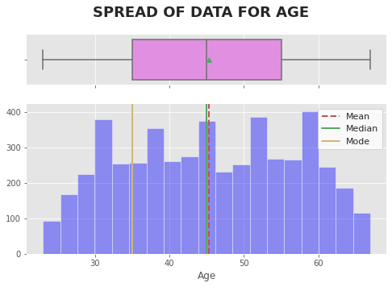

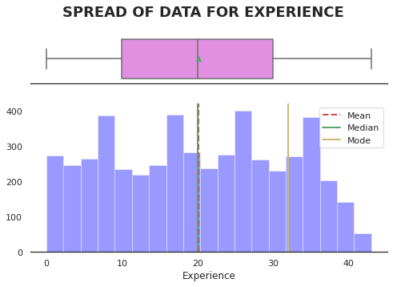

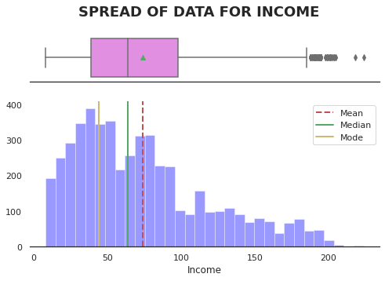

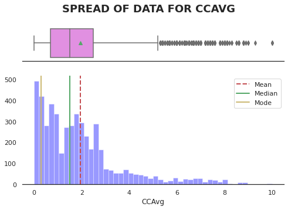

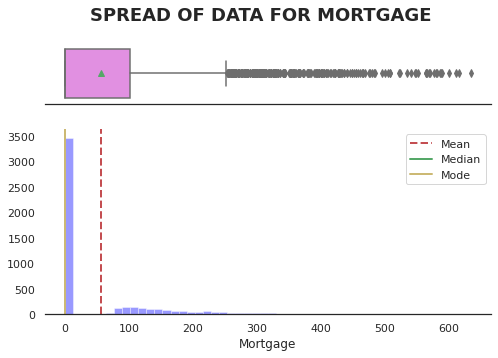

```python
#select all quantitative columns for checking the spread
list_col=  ['Age','Experience','Income','CCAvg','Mortgage']
for i in range(len(list_col)):
    dist_box(df_loan[list_col[i]])
```

**Observations**

- Age and experience both has same distrubtion with spike at 5 points.
- Income is right skewed and has some outlier on higher side which can be clipped.
- Average montly credit is right skewed and has lot of outliers on higher side which can be clipped.
- Mortgage is mostly 0 . but is right skewed and has lot of outlier on higher side which can be clipped.

### Age

Age can be a vital factor in borrowinng loan, converting ages to bin to explore if there is any pattern

```python
df_loan['Agebin'] = pd.cut(df_loan['Age'], bins = [0, 30, 40, 50, 60, 100], labels = ['18-30', '31-40', '41-50', '51-60', '60-100'])
```

### Income

To understand customers segments derving new columns which will help us identify if customer belongs to Upper , middle or lower income group

```python
# Create a new variable - Income group

df_loan["Income_group"] = pd.cut(
    x=df["Income"],
    bins=[0, 50, 140, 224],
    labels=["Lower", "Middle", "High"],
)
```

### Spending

To understand customers spending derving new columns which will say if customer belongs to Upper , middle or lower spending

```python
df_loan.CCAvg.describe()
```

```
count   5000.00000
mean       1.93794
std        1.74766
min        0.00000
25%        0.70000
50%        1.50000
75%        2.50000
max       10.00000
Name: CCAvg, dtype: float64
```

```python
df_loan["Spending_group"] = pd.cut( x=df_loan["CCAvg"], bins=[0.00000, 0.70000, 2.50000, 10.00000],
    labels=["Low", "Medium", "High"],include_lowest=True ,
)
```

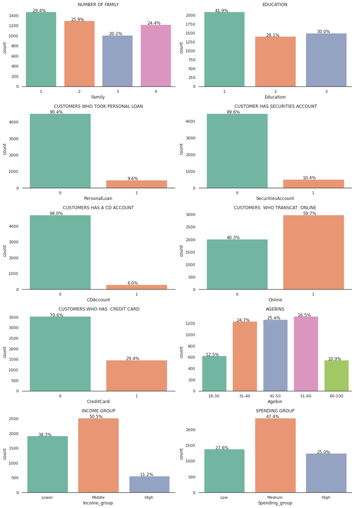

```python
# Making a list of all categorical variables
cat_columns = ['Family','Education','PersonalLoan','SecuritiesAccount',
               'CDAccount','Online','CreditCard','Agebin','Income_group','Spending_group']
title=['Number of Family','Education','Customers who took Personal Loan',
       ' Customer has Securities Account','Customers has a CD Account',
       'Customers  who transcat  Online',' Customers who has  Credit Card','Agebins',"Income group",'Spending group']
plt.figure(figsize=(14,20))

sns.set_theme(style="white") # just trying to make visualisation better. This will set background to white
#list_palette=['Blues_r','Greens_r','Purples_r','Reds_r','Blues_r','Greens_r','Purples_r','Reds_r','Blues_r']

for i, variable in enumerate(cat_columns):
                     plt.subplot(5,2,i+1)
                     order = df_loan[variable].value_counts(ascending=False).index
                     #sns.set_palette(list_palette[i]) # to set the palette
                     sns.set_palette('Set2')
                     ax=sns.countplot(x=df_loan[variable], data=df_loan )
                     sns.despine(top=True,right=True,left=True) # to remove side line from graph
                     for p in ax.patches:
                           percentage = '{:.1f}%'.format(100 * p.get_height()/len(df_loan[variable]))
                           x = p.get_x() + p.get_width() / 2 - 0.05
                           y = p.get_y() + p.get_height()
                           plt.annotate(percentage, (x, y),ha='center')
                     plt.tight_layout()
                     plt.title(title[i].upper())
```

**Observations**

- `~29.4 %` customers are single.
- `~41.9%` customers are undergrad.
- `~9.6%` bought a personal loan from the bank.
- `10.4 %` customers have a securities account with the bank
- `6 %` customer have a CD account.
- `60%` customers transact online.
- `29.4%` customers have credit cards.
- `~ 75 %` of customers are in range of 31- 60.
- `~ 50 %` Most of bank customers belong to middle income group.
- `~48 %` of customers has medium Average spending

```python
df_loan.groupby(['County','PersonalLoan'])['PersonalLoan'].agg({'size'}).unstack()
```

| PersonalLoan County | size 0 | size 1 |
| --- | --- | --- |
| 9307 | 1 | 0 |
| 96651 | 6 | 0 |
| Alameda County | 456 | 44 |
| Butte County | 17 | 2 |
| Contra Costa County | 73 | 12 |
| El Dorado County | 16 | 1 |
| Fresno County | 24 | 2 |
| Humboldt County | 30 | 2 |
| Imperial County | 3 | 0 |
| Kern County | 47 | 7 |
| Lake County | 4 | 0 |
| Los Angeles County | 984 | 111 |
| Marin County | 48 | 6 |
| Mendocino County | 7 | 1 |
| Merced County | 4 | 0 |
| Monterey County | 113 | 15 |
| Napa County | 3 | 0 |
| Orange County | 333 | 33 |
| Placer County | 22 | 2 |
| Riverside County | 50 | 6 |
| Sacramento County | 169 | 15 |
| San Benito County | 14 | 0 |
| San Bernardino County | 98 | 3 |
| San Diego County | 509 | 59 |
| San Francisco County | 238 | 19 |
| San Joaquin County | 12 | 1 |
| San Luis Obispo County | 28 | 5 |
| San Mateo County | 192 | 12 |
| Santa Barbara County | 143 | 11 |
| Santa Clara County | 492 | 71 |
| Santa Cruz County | 60 | 8 |
| Shasta County | 15 | 3 |
| Siskiyou County | 7 | 0 |
| Solano County | 30 | 3 |
| Sonoma County | 22 | 6 |
| Stanislaus County | 14 | 1 |
| Trinity County | 4 | 0 |
| Tuolumne County | 7 | 0 |
| Ventura County | 103 | 11 |
| Yolo County | 122 | 8 |

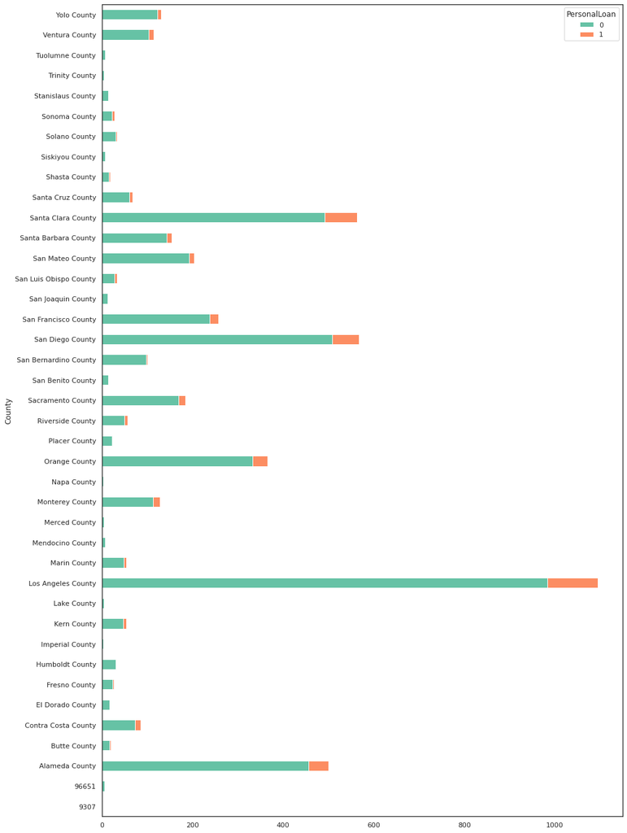

```python
plt.figure(figsize=(15,24))

pd.crosstab(index=df_loan['County'],columns=df_loan['PersonalLoan'].sort_values(ascending=False)).plot(kind='barh',stacked=True,figsize=(15,24))
```

**It can be seen the percentage of loan taken from various country differ.There are so many county converting them to regions will help in our model**

```python
counties = {
'Los Angeles County':'Los Angeles Region',
'San Diego County':'Southern',
'Santa Clara County':'Bay Area',
'Alameda County':'Bay Area',
'Orange County':'Southern',
'San Francisco County':'Bay Area',
'San Mateo County':'Bay Area',
'Sacramento County':'Central',
'Santa Barbara County':'Southern',
'Yolo County':'Central',
'Monterey County':'Bay Area',
'Ventura County':'Southern',
'San Bernardino County':'Southern',
'Contra Costa County':'Bay Area',
'Santa Cruz County':'Bay Area',
'Riverside County':'Southern',
'Kern County':'Southern',
'Marin County':'Bay Area',
'San Luis Obispo County':'Southern',
'Solano County':'Bay Area',
'Humboldt County':'Superior',
'Sonoma County':'Bay Area',
'Fresno County':'Central',
'Placer County':'Central',
'Butte County':'Superior',
'Shasta County':'Superior',
'El Dorado County':'Central',
'Stanislaus County':'Central',
'San Benito County':'Bay Area',
'San Joaquin County':'Central',
'Mendocino County':'Superior',
'Tuolumne County':'Central',
'Siskiyou County':'Superior',
'Trinity County':'Superior',
'Merced County':'Central',
'Lake County':'Superior',
'Napa County':'Bay Area',
'Imperial County':'Southern',
93077:'Southern',
96651:'Bay Area'
}
```

**Converting the county to regions based on https://www.calbhbc.org/region-map-and-listing.html**

```python
df_loan['Regions'] = df_loan['County'].map(counties)
```

```python
df_loan['Regions'].unique()
```

```
array(['Los Angeles Region', 'Bay Area', 'Southern', 'Superior',
       'Central', nan], dtype=object)
```

```python
df_loan.isnull().sum()
```

```
Age                  0
Experience           0
Income               0
ZIPCode              0
Family               0
CCAvg                0
Education            0
Mortgage             0
PersonalLoan         0
SecuritiesAccount    0
CDAccount            0
Online               0
CreditCard           0
County               0
Agebin               0
Income_group         0
Spending_group       0
Regions              1
dtype: int64
```

```python
df_loan.dropna(inplace=True)
```

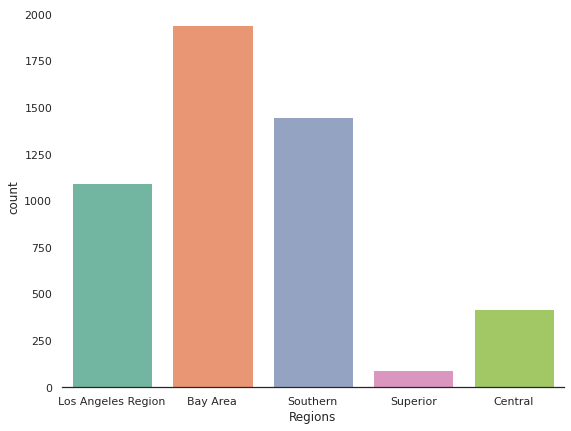

```python
plt.figure(figsize=(9,7))
sns.countplot(data=df_loan,x=df_loan['Regions'])
sns.despine(top=True,right=True,left=True) # to remove side line from graph
```

### Bivariate & Multivariate Analysis

```python
df_loan.info()
```

```
<class 'pandas.core.frame.DataFrame'>
Int64Index: 4999 entries, 0 to 4999
Data columns (total 18 columns):
 #   Column             Non-Null Count  Dtype
---  ------             --------------  -----
 0   Age                4999 non-null   int64
 1   Experience         4999 non-null   int64
 2   Income             4999 non-null   int64
 3   ZIPCode            4999 non-null   category
 4   Family             4999 non-null   category
 5   CCAvg              4999 non-null   float64
 6   Education          4999 non-null   category
 7   Mortgage           4999 non-null   int64
 8   PersonalLoan       4999 non-null   category
 9   SecuritiesAccount  4999 non-null   category
 10  CDAccount          4999 non-null   category
 11  Online             4999 non-null   category
 12  CreditCard         4999 non-null   category
 13  County             4999 non-null   category
 14  Agebin             4999 non-null   category
 15  Income_group       4999 non-null   category
 16  Spending_group     4999 non-null   category
 17  Regions            4999 non-null   object
dtypes: category(12), float64(1), int64(4), object(1)
memory usage: 488.5+ KB
```

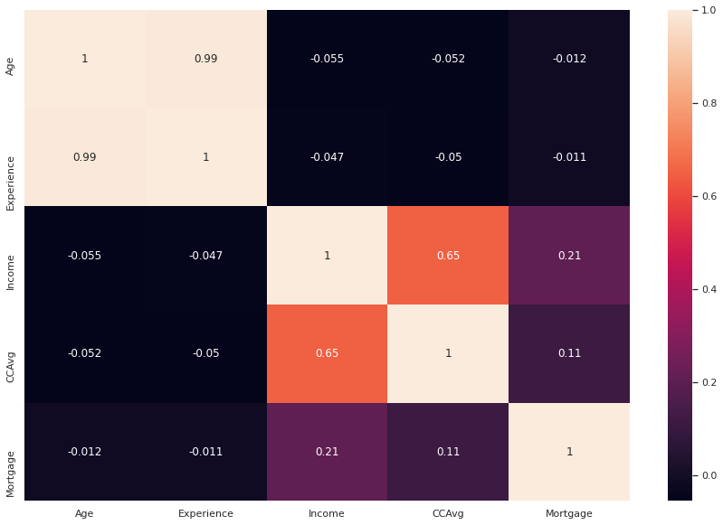

```python
sns.set_palette(sns.color_palette("Set2", 8))
plt.figure(figsize=(15,10))
sns.heatmap(df_loan.corr(),annot=True)
plt.show()
```

**Observations**

- As expected Age and experience are highly correlated and one of them can be dropped.Since we had to handle 0, will drop experience.
- Income and Average spending on credit card are positively corrleated.
- Mortgage has very little correlation with income.

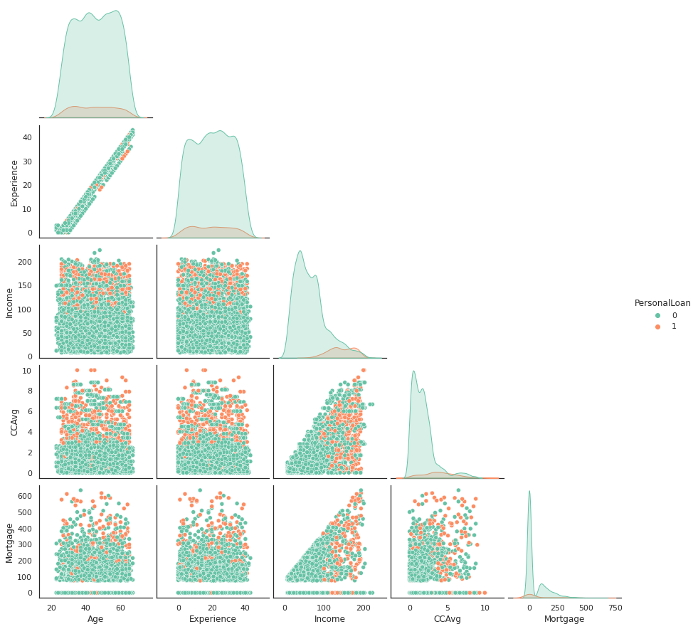

```python
sns.set_palette(sns.color_palette("Set2", 8))
sns.pairplot(df_loan, hue="PersonalLoan",corner=True)
plt.show()
```

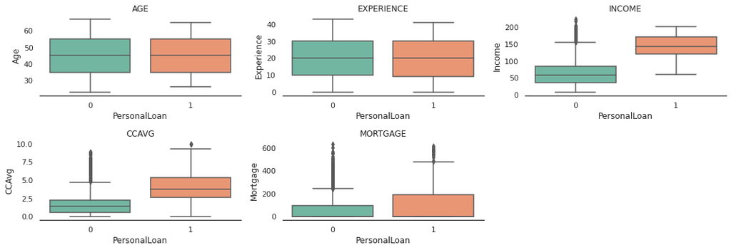

```python
numeric_columns = ['Age','Experience','Income','CCAvg','Mortgage']
plt.figure(figsize=(15,25))

sns.set_palette(sns.color_palette("Set2", 8))
for i, variable in enumerate(numeric_columns):
        plt.subplot(10,3,i+1)

        sns.boxplot(x='PersonalLoan',y= df_loan[variable], data=df_loan)
        sns.despine(top=True,right=True,left=True) # to remove side line from graph
        plt.tight_layout()
        plt.title(variable.upper())
```

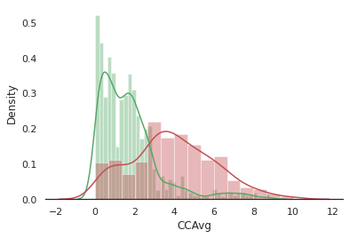

```python
sns.distplot( df_loan[df_loan['PersonalLoan'] == 0]['CCAvg'], color = 'g')
sns.distplot( df_loan[df_loan['PersonalLoan'] == 1]['CCAvg'], color = 'r')
sns.despine(top=True,right=True,left=True) # to remove side line from graph
```

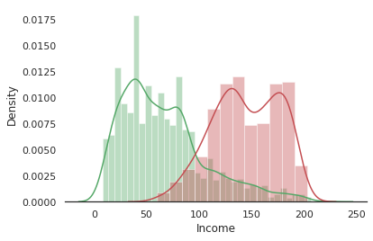

```python
sns.distplot( df_loan[df_loan['PersonalLoan'] == 0]['Income'], color = 'g')
sns.distplot( df_loan[df_loan['PersonalLoan'] == 1]['Income'], color = 'r')
sns.despine(top=True,right=True,left=True) # to remove side line from graph
```

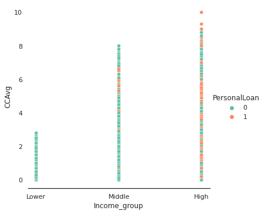

```python
sns.relplot(x='Income_group',y='CCAvg',hue='PersonalLoan',data=df_loan)
sns.despine(top=True,right=True,left=True) # to remove side line from graph
```

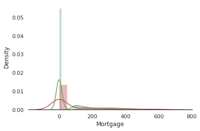

```python
sns.distplot( df_loan[df_loan['PersonalLoan'] == 0]['Mortgage'], color = 'g')
sns.distplot( df_loan[df_loan['PersonalLoan'] == 1]['Mortgage'], color = 'r')
sns.despine(top=True,right=True,left=True) # to remove side line from graph
```

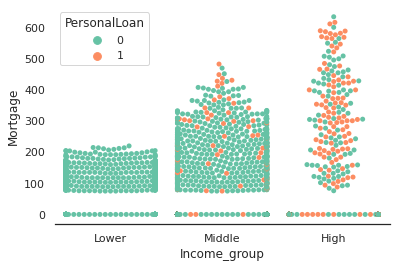

```python
sns.swarmplot(x='Income_group',y='Mortgage',hue='PersonalLoan',data=df_loan)
sns.despine(top=True,right=True,left=True) # to remove side line from graph
```

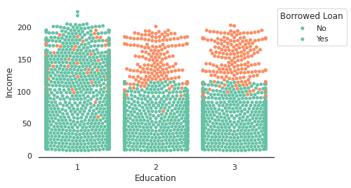

```python
sns.swarmplot(x='Education',y='Income',hue='PersonalLoan',data=df_loan)
sns.despine(top=True,right=True,left=True) # to remove side line from graph
labels=["No","Yes"]
plt.legend(loc='lower left', frameon=False,)
plt.legend(loc="upper left", labels=labels,title="Borrowed Loan",bbox_to_anchor=(1,1))
```

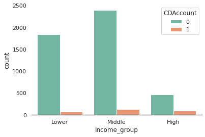

```python
sns.countplot(x='Income_group',hue='CDAccount',data=df_loan)
sns.despine(top=True,right=True,left=True) # to remove side line from graph
```

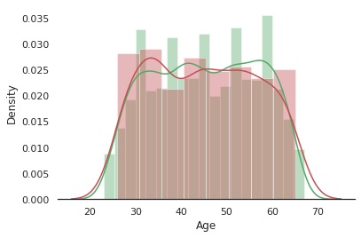

```python
sns.distplot( df_loan[df_loan['PersonalLoan'] == 0]['Age'], color = 'g')
sns.distplot( df_loan[df_loan['PersonalLoan'] == 1]['Age'], color = 'r')
sns.despine(top=True,right=True,left=True) # to remove side line from graph
```

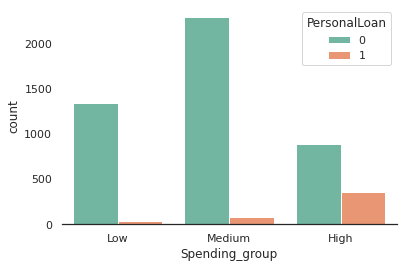

```python
sns.countplot(x='Spending_group',hue='PersonalLoan',data=df_loan)

sns.despine(top=True,right=True,left=True) # to remove side line from graph
```

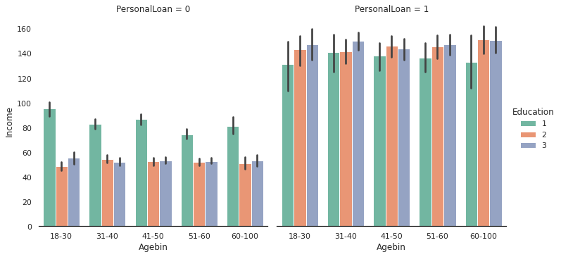

```python
sns.catplot(y='Income',x='Agebin',hue='Education',kind='bar',col="PersonalLoan", data=df_loan)
sns.despine(top=True,right=True,left=True) # to remove side line from graph
```

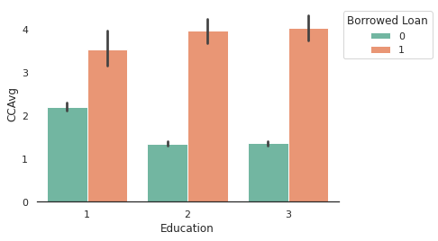

```python
sns.set_palette(sns.color_palette("Set2", 8))
sns.barplot(y='CCAvg',x='Education', hue='PersonalLoan',data=df_loan)
labels=["No","Yes"]
plt.legend(loc="upper left", title="Borrowed Loan",bbox_to_anchor=(1,1))
sns.despine(top=True,right=True,left=True) # to remove side line from graph
```

**Observations**